# Simplilearn Post Graduate Program - Data Science

#### Task I (f): Scatter Charts between the pair of variables to understand the relationships.

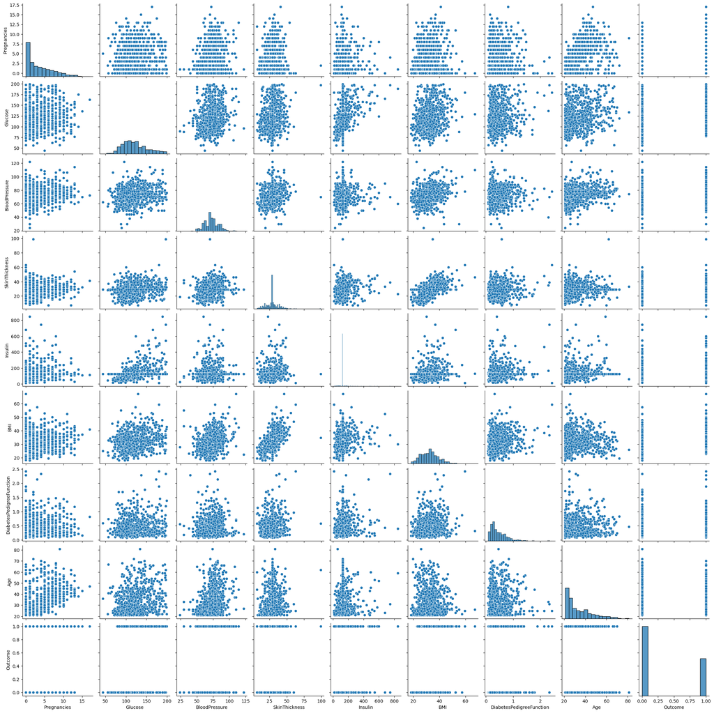

```python
# pairwise scatter plot of the dataset columns

sns.pairplot(diabetes_data_missing_imputed);
```

#### Task I (g): Correlation analysis using Heatmap

```python
# getting correlation of the data columns with each other

corr_data = diabetes_data_missing_imputed.corr().round(2)
corr_data
```

|  | Pregnancies | Glucose | BloodPressure | SkinThickness | Insulin | BMI | DiabetesPedigreeFunction | Age | Outcome |
| --- | --- | --- | --- | --- | --- | --- | --- | --- | --- |
| Pregnancies | 1.00 | 0.13 | 0.21 | 0.08 | 0.03 | 0.02 | -0.03 | 0.54 | 0.22 |
| Glucose | 0.13 | 1.00 | 0.22 | 0.19 | 0.42 | 0.23 | 0.14 | 0.27 | 0.49 |
| BloodPressure | 0.21 | 0.22 | 1.00 | 0.19 | 0.05 | 0.28 | -0.00 | 0.33 | 0.16 |
| SkinThickness | 0.08 | 0.19 | 0.19 | 1.00 | 0.15 | 0.54 | 0.10 | 0.13 | 0.22 |
| Insulin | 0.03 | 0.42 | 0.05 | 0.15 | 1.00 | 0.18 | 0.13 | 0.10 | 0.20 |
| BMI | 0.02 | 0.23 | 0.28 | 0.54 | 0.18 | 1.00 | 0.15 | 0.03 | 0.31 |
| DiabetesPedigreeFunction | -0.03 | 0.14 | -0.00 | 0.10 | 0.13 | 0.15 | 1.00 | 0.03 | 0.17 |
| Age | 0.54 | 0.27 | 0.33 | 0.13 | 0.10 | 0.03 | 0.03 | 1.00 | 0.24 |
| Outcome | 0.22 | 0.49 | 0.16 | 0.22 | 0.20 | 0.31 | 0.17 | 0.24 | 1.00 |

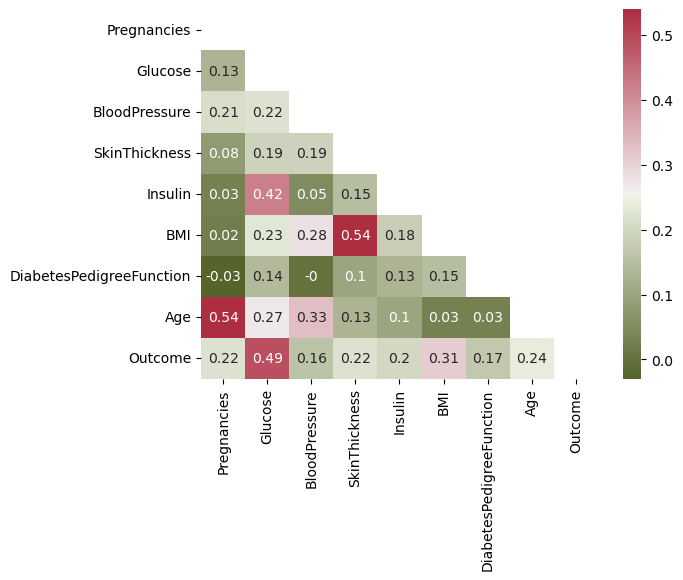

```python
# Getting the Upper Triangle of the co-relation matrix
matrix = np.triu(np.ones_like(corr_data))

# Create a custom divergin palette
cmap = sns.diverging_palette(100, 7, s=75, l=40,
                            n=5, center="light", as_cmap=True)

# using the upper triangle matrix as mask
sns.heatmap(corr_data, annot=True, mask=matrix, cmap=cmap);
```

#### Task I (h): Outlier Detection and treatment

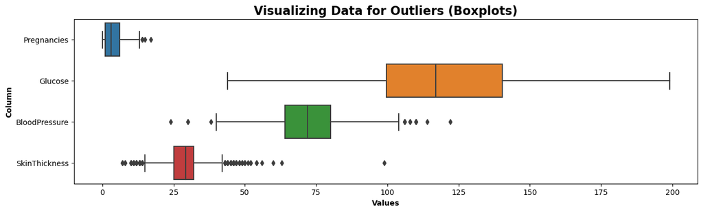

```python
plt.figure(figsize=(15,4))

sns.boxplot(data = diabetes_data_missing_imputed[diabetes_data_missing_imputed.columns[:4]], orient='h');
plt.title('Visualizing Data for Outliers (Boxplots)', fontsize = 16, fontweight="bold")
plt.xlabel('Values', fontweight="bold")
plt.ylabel('Column', fontweight="bold")
plt.show()
```

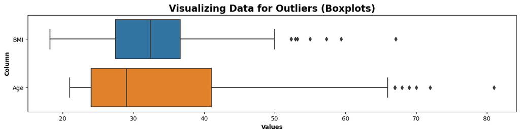

```python
plt.figure(figsize=(15,3))

sns.boxplot(data = diabetes_data_missing_imputed[['BMI', 'Age']], orient='h');
plt.title('Visualizing Data for Outliers (Boxplots)', fontsize = 16, fontweight="bold")
plt.xlabel('Values', fontweight="bold")
plt.ylabel('Column', fontweight="bold")
plt.show()
```

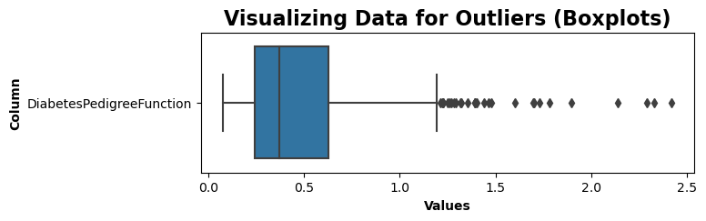

```python
plt.figure(figsize=(7,2))

sns.boxplot(data = diabetes_data_missing_imputed[['DiabetesPedigreeFunction']], orient='h');
plt.title('Visualizing Data for Outliers (Boxplots)', fontsize = 16, fontweight="bold")
plt.xlabel('Values', fontweight="bold")
plt.ylabel('Column', fontweight="bold")
plt.show()
```

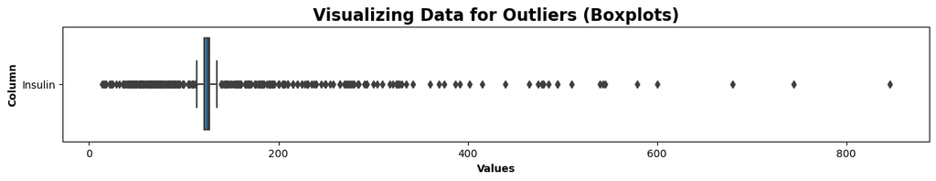

```python
plt.figure(figsize=(15,2))

sns.boxplot(data = diabetes_data_missing_imputed[['Insulin']], orient='h');
plt.title('Visualizing Data for Outliers (Boxplots)', fontsize = 16, fontweight="bold")
plt.xlabel('Values', fontweight="bold")
plt.ylabel('Column', fontweight="bold")
plt.show()
```

```python
# this function takes the column and the dataframe and returns the total number of outliers and the percent of outliers
# based on IQR (i.e. based on 25th and 75th percentile values)

def find_outliers_stats(col, df):

    percentile25 = df[col].quantile(0.25)
    percentile75 = df[col].quantile(0.75)

    iqr = percentile75 - percentile25

    upper_limit = percentile75 + (1.5 * iqr)
    lower_limit = percentile25 - (1.5 * iqr)

    outliers_count = len(df[df[col] > upper_limit]) + len(df[df[col] < lower_limit])
    outliers_percent = round((outliers_count/df.shape[0])*100,2)

    return outliers_count, outliers_percent
```

```python
diabetes_data_without_missing_vals.columns
```

```
Index(['Glucose', 'BloodPressure', 'SkinThickness', 'Insulin', 'BMI',
       'Pregnancies', 'DiabetesPedigreeFunction', 'Age', 'Outcome'],
      dtype='object')
```

```python
# this function iterates over the columns of the passed df, and internally calls 'find_outliers_stats' function to get the
# outlier count and percent. The reason that I have seperate function then 'find_outliers_stats' is because
# it gives more freedom. If I want outlier count and percent of single column, 'find_outliers_stats' function can be used.
# If I want it for the list of columns or for all the columns of passed dataframe, 'outlier_stats' function can be used.

def outlier_stats(df):

    outlier_stats = dict()

    for c in df.columns[:-1]:
        vals = find_outliers_stats(c, df)
        outlier_stats[c] = vals

    df_outlier_stats = pd.DataFrame(outlier_stats, index=['no_of_outliers', 'no_of_outliers_percent']).T
    return df_outlier_stats
```

```python
# checking the outliers percent of the data for which missing values were "removed"

outlier_stats_of_data_with_no_missing_vals = outlier_stats(diabetes_data_without_missing_vals)
outlier_stats_of_data_with_no_missing_vals
```

|  | no_of_outliers | no_of_outliers_percent |
| --- | --- | --- |
| Glucose | 0.0 | 0.00 |
| BloodPressure | 7.0 | 1.79 |
| SkinThickness | 1.0 | 0.26 |
| Insulin | 25.0 | 6.38 |
| BMI | 6.0 | 1.53 |
| Pregnancies | 11.0 | 2.81 |
| DiabetesPedigreeFunction | 12.0 | 3.06 |
| Age | 13.0 | 3.32 |

```python
# checking the outliers percent of the data for which missing values were "imputed"

outlier_stats_after_missing_imputation = outlier_stats(diabetes_data_missing_imputed)
outlier_stats_after_missing_imputation
```

|  | no_of_outliers | no_of_outliers_percent |
| --- | --- | --- |
| Pregnancies | 4.0 | 0.52 |
| Glucose | 0.0 | 0.00 |
| BloodPressure | 14.0 | 1.82 |
| SkinThickness | 87.0 | 11.33 |
| Insulin | 346.0 | 45.05 |
| BMI | 8.0 | 1.04 |
| DiabetesPedigreeFunction | 29.0 | 3.78 |
| Age | 9.0 | 1.17 |

```python
# re-imputing the missing values of the 'Insulin' column with mean values of 'Insulin column' of the data without missing values

col = 'Insulin'

diabetes_data_missing_imputed[col] = diabetes_data[col].apply(
                                                        lambda x: np.mean(diabetes_data_without_missing_vals[col]) if x == 0 else x)
```

```python
# checking outliers stats after imputation

outlier_stats_after_missing_imputation = outlier_stats(diabetes_data_missing_imputed)
outlier_stats_after_missing_imputation
```

|  | no_of_outliers | no_of_outliers_percent |
| --- | --- | --- |
| Pregnancies | 4.0 | 0.52 |
| Glucose | 0.0 | 0.00 |
| BloodPressure | 14.0 | 1.82 |
| SkinThickness | 87.0 | 11.33 |
| Insulin | 159.0 | 20.70 |
| BMI | 8.0 | 1.04 |
| DiabetesPedigreeFunction | 29.0 | 3.78 |
| Age | 9.0 | 1.17 |

```python
# checking mean and standard deviation of 'Insulin' column from the data where missing values were removed

np.mean(diabetes_data_without_missing_vals['Insulin']), np.std(diabetes_data_without_missing_vals['Insulin'])
```

```
(156.05612244897958, 118.69000917870957)
```

```python
# checking the value of mean + standard deviation of 'Insulin' column from the data where missing values were removed

np.mean(diabetes_data_without_missing_vals['Insulin']) + np.std(diabetes_data_without_missing_vals['Insulin'])
```

```
274.7461316276891
```

```python
# checking the value of mean - standard deviation of 'Insulin' column from the data where missing values were removed

np.mean(diabetes_data_without_missing_vals['Insulin']) - np.std(diabetes_data_without_missing_vals['Insulin'])
```

```
37.366113270270006
```

```python
# re-imputation of Insulin column with impute_value (mean of 'Insulin' - standard deviation of 'Insulin')

col = 'Insulin'

impute_value = np.mean(diabetes_data_without_missing_vals[col]) - np.std(diabetes_data_without_missing_vals[col])

diabetes_data_missing_imputed[col] = diabetes_data[col].apply(
                                                        lambda x: impute_value if x == 0 else x)
```

```python
# checking outliers stats after imputation

outlier_stats_after_missing_imputation = outlier_stats(diabetes_data_missing_imputed)
outlier_stats_after_missing_imputation
```

|  | no_of_outliers | no_of_outliers_percent |
| --- | --- | --- |
| Pregnancies | 4.0 | 0.52 |
| Glucose | 0.0 | 0.00 |
| BloodPressure | 14.0 | 1.82 |
| SkinThickness | 87.0 | 11.33 |
| Insulin | 54.0 | 7.03 |
| BMI | 8.0 | 1.04 |
| DiabetesPedigreeFunction | 29.0 | 3.78 |
| Age | 9.0 | 1.17 |

```python
# re-imputation of Insulin column with impute_value (mean of 'Insulin' - standard deviation of 'Insulin')

col = 'Insulin'

impute_value = np.mean(diabetes_data_without_missing_vals[col]) + np.std(diabetes_data_without_missing_vals[col])

diabetes_data_missing_imputed[col] = diabetes_data[col].apply(
                                                        lambda x: impute_value if x == 0 else x)
```

```python
# checking outliers stats after imputation

outlier_stats_after_missing_imputation = outlier_stats(diabetes_data_missing_imputed)
outlier_stats_after_missing_imputation
```

|  | no_of_outliers | no_of_outliers_percent |
| --- | --- | --- |
| Pregnancies | 4.0 | 0.52 |
| Glucose | 0.0 | 0.00 |
| BloodPressure | 14.0 | 1.82 |
| SkinThickness | 87.0 | 11.33 |
| Insulin | 9.0 | 1.17 |
| BMI | 8.0 | 1.04 |
| DiabetesPedigreeFunction | 29.0 | 3.78 |
| Age | 9.0 | 1.17 |

```python
# fuction which accepts the column and dataframe and returns a dataframe with removed outliers of the passed column

def outliar_removal(col, df):

    percentile25 = df[col].quantile(0.25)
    percentile75 = df[col].quantile(0.75)

#     print(f'For column {col}:\n')
#     print(f'25th Percentile: {percentile25}')
#     print(f'75th Percentile: {percentile75}')

    iqr = percentile75 - percentile25

#     print(f'IQR: {iqr}\n')

    upper_limit = percentile75 + (1.5 * iqr)
    lower_limit = percentile25 - (1.5 * iqr)

    rows_before = df.shape[0]

    df = df[df[col] < upper_limit]
    df = df[df[col] > lower_limit]

    print(f'Column in consideration: {col}')
    print(f'Current number of rows: {rows_before}')
    print(f'Rows removed: {rows_before - df.shape[0]}')
    print(f'Rows removed (in %): { round(((rows_before - df.shape[0])/rows_before)*100,2)}\n\n')

    return df
```

```python
# removing the outliers of the columns one by one using loop via 'outliar_removal' function

diabetes_data_missing_imputed_outlier_removed = diabetes_data_missing_imputed.copy(deep = True)

for col in diabetes_data_missing_imputed_outlier_removed.columns[:-1]:
    diabetes_data_missing_imputed_outlier_removed = outliar_removal(col, diabetes_data_missing_imputed_outlier_removed)
```

```
Column in consideration: Pregnancies
Current number of rows: 768
Rows removed: 4
Rows removed (in %): 0.52


Column in consideration: Glucose
Current number of rows: 764
Rows removed: 0
Rows removed (in %): 0.0


Column in consideration: BloodPressure
Current number of rows: 764
Rows removed: 17
Rows removed (in %): 2.23


Column in consideration: SkinThickness
Current number of rows: 747
Rows removed: 85
Rows removed (in %): 11.38


Column in consideration: Insulin
Current number of rows: 662
Rows removed: 7
Rows removed (in %): 1.06


Column in consideration: BMI
Current number of rows: 655
Rows removed: 6
Rows removed (in %): 0.92


Column in consideration: DiabetesPedigreeFunction
Current number of rows: 649
Rows removed: 27
Rows removed (in %): 4.16


Column in consideration: Age
Current number of rows: 622
Rows removed: 9
Rows removed (in %): 1.45
```

```python
diabetes_data_missing_imputed_outlier_removed.columns
```

```
Index(['Pregnancies', 'Glucose', 'BloodPressure', 'SkinThickness', 'Insulin',
       'BMI', 'DiabetesPedigreeFunction', 'Age', 'Outcome'],
      dtype='object')
```

Visualizing columns through boxplots after removal of outliers

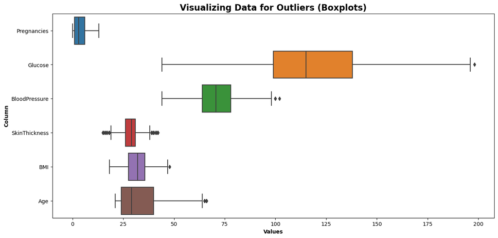

```python
plt.figure(figsize=(15,7))

cols = ['Pregnancies', 'Glucose', 'BloodPressure', 'SkinThickness', 'BMI', 'Age']

sns.boxplot(data = diabetes_data_missing_imputed_outlier_removed[cols], orient='h');
plt.title('Visualizing Data for Outliers (Boxplots)', fontsize = 16, fontweight="bold")
plt.xlabel('Values', fontweight="bold")
plt.ylabel('Column', fontweight="bold")
plt.show()
```

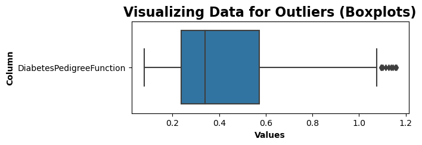

```python
plt.figure(figsize=(6,2))

sns.boxplot(data = diabetes_data_missing_imputed_outlier_removed[['DiabetesPedigreeFunction']], orient='h');
plt.title('Visualizing Data for Outliers (Boxplots)', fontsize = 16, fontweight="bold")
plt.xlabel('Values', fontweight="bold")
plt.ylabel('Column', fontweight="bold")
plt.show()
```

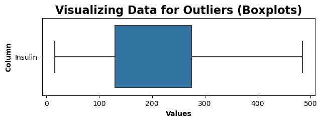

```python
plt.figure(figsize=(7,2))

sns.boxplot(data = diabetes_data_missing_imputed_outlier_removed[['Insulin']], orient='h');
plt.title('Visualizing Data for Outliers (Boxplots)', fontsize = 16, fontweight="bold")
plt.xlabel('Values', fontweight="bold")
plt.ylabel('Column', fontweight="bold")
plt.show()
```

**Analysis Summary*:

- From the pairwise scatter plot, following are the relationship among columns identified:

  ```
    * Glucose with Insulin
    * BMI with BloodPressure
    * Pregnancies with Age
    * BMI with SkinThickness
  ```

- The above relationship was further verified with Correlation Matrix as heatmap and was found that the following columns were related:

  ```
    * Glucose with Insulin
    * BMI with Skinthickness
    * Pregnancies with Age
  ```

- However, because the values were less than 0.6, the above correlations were disregarded,
- It was found the except Glucose column, all the other independent variables had outliers present.
- Also, during reinspection of outliers (via values), it was observed that Insulin column had invariably large number of outliers present.
- So this Insulin column was reimputed with mean and standard deviation values. The appropriate value was settled at mean + standard deviation, as this gave minimum number of outliers.
- Therefore, the outliers were removed by keeping only the values within 25th and 75th percentile ± 1.5 times IQR values of the respective column

### Task II: Data Modeling

#### Task II (a): Splitting of Data

```python
X = diabetes_data_missing_imputed_outlier_removed.drop(['Outcome'], axis = 1)
y = diabetes_data_missing_imputed_outlier_removed['Outcome']
```

```python
X_train, X_test, y_train, y_test = train_test_split(X, y, test_size=0.15, random_state=48)
```

```python
X_train.shape, X_test.shape
```

```
((521, 8), (92, 8))
```

```python
y_train.shape, y_test.shape
```

```
((521,), (92,))
```

#### Task II (b): Scaling of the Data

```python
X_train[X_train < 0].any().sum(), X_test[X_test < 0].any().sum()
```

```
(0, 0)
```

```python
cols_X = X_train.columns
```

```python
scaler = MinMaxScaler()

X_train = pd.DataFrame(scaler.fit_transform(X_train), columns=cols_X)
X_test = pd.DataFrame(scaler.transform(X_test), columns=cols_X)
```

```python
scaler.get_feature_names_out()
```

```
array(['Pregnancies', 'Glucose', 'BloodPressure', 'SkinThickness',
       'Insulin', 'BMI', 'DiabetesPedigreeFunction', 'Age'], dtype=object)
```

```python
scaler.get_params()
```

```
{'clip': False, 'copy': True, 'feature_range': (0, 1)}
```

```python
X_train.head()
```

|  | Pregnancies | Glucose | BloodPressure | SkinThickness | Insulin | BMI | DiabetesPedigreeFunction | Age |
| --- | --- | --- | --- | --- | --- | --- | --- | --- |
| 0 | 0.230769 | 0.857143 | 0.750000 | 0.444444 | 0.298507 | 0.508418 | 0.995375 | 0.688889 |
| 1 | 0.000000 | 0.448052 | 0.642857 | 0.037037 | 0.551698 | 0.430976 | 0.736355 | 0.000000 |
| 2 | 0.615385 | 0.136364 | 0.500000 | 0.296296 | 0.551698 | 0.464646 | 0.482886 | 0.466667 |
| 3 | 0.076923 | 0.532468 | 0.285714 | 0.523904 | 0.551698 | 0.400673 | 0.250694 | 0.577778 |
| 4 | 0.076923 | 0.175325 | 0.071429 | 0.111111 | 0.127932 | 0.074074 | 0.226642 | 0.022222 |

```python
X_test.head()
```

|  | Pregnancies | Glucose | BloodPressure | SkinThickness | Insulin | BMI | DiabetesPedigreeFunction | Age |
| --- | --- | --- | --- | --- | --- | --- | --- | --- |
| 0 | 0.461538 | 0.675325 | 0.500000 | 0.740741 | 0.551698 | 0.518519 | 0.507863 | 0.644444 |
| 1 | 0.461538 | 0.435065 | 0.357143 | 0.888889 | 0.551698 | 0.538721 | 0.168363 | 0.066667 |
| 2 | 0.076923 | 0.733766 | 0.500000 | 0.222222 | 0.324094 | 0.249158 | 0.041628 | 0.066667 |
| 3 | 0.692308 | 0.441558 | 0.678571 | 0.629630 | 0.339019 | 0.538721 | 0.168363 | 0.333333 |
| 4 | 0.076923 | 0.474026 | 0.285714 | 0.296296 | 0.191898 | 0.525253 | 0.358927 | 0.133333 |

#### Task II (c): Finding Principle Components to reduce dataset Dimention (PCA)

```python
X_train_covariance_matrix = np.cov(X_train.T)
```

```python
X_train_covariance_matrix.shape
```

```
(8, 8)
```

```python
eig_vals, eig_vecs = np.linalg.eig(X_train_covariance_matrix)
```

```python
# Make a list of (eigenvalue, eigenvector) tuples
eig_pairs = [(np.abs(eig_vals[i]), eig_vecs[:,i]) for i in range(len(eig_vals))]

# Sort the (eigenvalue, eigenvector) tuples from high to low
eig_pairs.sort(key=lambda x: x[0], reverse=True)
```

```python
# Visually confirm that the list is correctly sorted by decreasing eigenvalues

print('Eigenvalues in descending order: \n')
for i in eig_pairs:   # first 5 values
    print(i[0])
```

```
Eigenvalues in descending order:

0.1071646092785274
0.07019661864203482
0.05038791668180087
0.04115853810931163
0.033448586737969944
0.026781469126898123
0.024184039973273588
0.02050363671641903
```

```python
tot = sum(eig_vals)
var_exp = [(i / tot)*100 for i in sorted(eig_vals, reverse=True)]  # Variance captured by each component
cum_var_exp = np.cumsum(var_exp)

# Since the cumulative variance is in complex form,
cum_var_exp = np.round(np.real(cum_var_exp),2)

print("Cumulative variance: \n\n", cum_var_exp)
```

```
Cumulative variance:

 [ 28.67  47.44  60.92  71.93  80.88  88.05  94.52 100.  ]
```

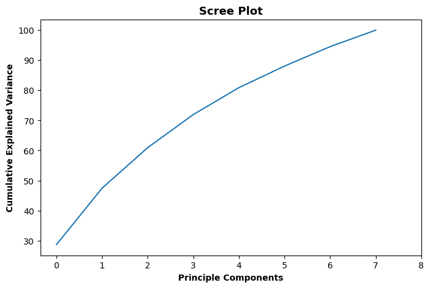

```python
plt.figure(figsize=(8,5))
sns.lineplot(x = range(X_train.shape[1]), y = cum_var_exp);
plt.title('Scree Plot', fontsize = 13, fontweight="bold")
plt.xlabel('Principle Components', fontweight="bold")
plt.ylabel('Cumulative Explained Variance', fontweight="bold")

plt.xticks(range(0, 9, 1))
#plt.yticks(range(0, 101, 10))

plt.show()
```

```python
components = np.where(cum_var_exp>94)[0][0]  # First index of Principle component which has captured upto 94% variance
components
```

```
6
```

```python
# defining PCA with components to capture 98% variance
pca = PCA(n_components=components+1)
```

```python
X_train_pc = pca.fit_transform(X_train)
```

```python
X_test_pc = pca.transform(X_test)
```

```python
X_train.shape, X_train_pc.shape
```

```
((521, 8), (521, 7))
```

```python
X_test.shape, X_test_pc.shape
```

```
((92, 8), (92, 7))
```

**Analysis Summary**:

- Dataset was splitted in training and testing set, in 85% and 15% ratio respectively.
- Splitted data was scaled using MinMax Scaler, because not all columns follow normal distribution
- Principle Component Analysis (PCA) was also performed in the dataset. It was observed that about 94% of the explained variance was captured by 7 columns, whereas the dataset has 8 columns (independent features)
- Therefore, in this particular dataset, the principle components aren’t useful because there is no significant reduction of features observed.

#### Task II (d): Examining the appropriate (baseline) model using DABL

- Since this is a Supervised Classification problem, we will use classification Machine Learning Algorithms.
- As the Outcome (Target) variable is not balanced, it would be appropriate to use tree models or ensemble models.
- However, it is to good to test this dataset with DABL package, which can give us a rough estimate on how the dataset will perform on different models. From this baseline, ideas can be followed up to select the best model further.

```python
ref_model = dabl.SimpleClassifier(random_state=0).fit(diabetes_data_missing_imputed_outlier_removed, target_col="Outcome")
ref_model
```

```
Running DummyClassifier()
accuracy: 0.672 average_precision: 0.328 roc_auc: 0.500 recall_macro: 0.500 f1_macro: 0.402
=== new best DummyClassifier() (using recall_macro):
accuracy: 0.672 average_precision: 0.328 roc_auc: 0.500 recall_macro: 0.500 f1_macro: 0.402

Running GaussianNB()
accuracy: 0.715 average_precision: 0.540 roc_auc: 0.743 recall_macro: 0.650 f1_macro: 0.655
=== new best GaussianNB() (using recall_macro):
accuracy: 0.715 average_precision: 0.540 roc_auc: 0.743 recall_macro: 0.650 f1_macro: 0.655

Running MultinomialNB()
accuracy: 0.669 average_precision: 0.491 roc_auc: 0.676 recall_macro: 0.561 f1_macro: 0.550
Running DecisionTreeClassifier(class_weight='balanced', max_depth=1)
accuracy: 0.632 average_precision: 0.438 roc_auc: 0.661 recall_macro: 0.661 f1_macro: 0.620
=== new best DecisionTreeClassifier(class_weight='balanced', max_depth=1) (using recall_macro):
accuracy: 0.632 average_precision: 0.438 roc_auc: 0.661 recall_macro: 0.661 f1_macro: 0.620

Running DecisionTreeClassifier(class_weight='balanced', max_depth=5)
accuracy: 0.685 average_precision: 0.558 roc_auc: 0.729 recall_macro: 0.693 f1_macro: 0.670
=== new best DecisionTreeClassifier(class_weight='balanced', max_depth=5) (using recall_macro):
accuracy: 0.685 average_precision: 0.558 roc_auc: 0.729 recall_macro: 0.693 f1_macro: 0.670

Running DecisionTreeClassifier(class_weight='balanced', min_impurity_decrease=0.01)
accuracy: 0.710 average_precision: 0.577 roc_auc: 0.744 recall_macro: 0.709 f1_macro: 0.689
=== new best DecisionTreeClassifier(class_weight='balanced', min_impurity_decrease=0.01) (using recall_macro):
accuracy: 0.710 average_precision: 0.577 roc_auc: 0.744 recall_macro: 0.709 f1_macro: 0.689

Running LogisticRegression(C=0.1, class_weight='balanced', max_iter=1000)
accuracy: 0.736 average_precision: 0.706 roc_auc: 0.828 recall_macro: 0.726 f1_macro: 0.713
=== new best LogisticRegression(C=0.1, class_weight='balanced', max_iter=1000) (using recall_macro):
accuracy: 0.736 average_precision: 0.706 roc_auc: 0.828 recall_macro: 0.726 f1_macro: 0.713

Running LogisticRegression(class_weight='balanced', max_iter=1000)
accuracy: 0.727 average_precision: 0.707 roc_auc: 0.822 recall_macro: 0.716 f1_macro: 0.704

Best model:
LogisticRegression(C=0.1, class_weight='balanced', max_iter=1000)
Best Scores:
accuracy: 0.736 average_precision: 0.706 roc_auc: 0.828 recall_macro: 0.726 f1_macro: 0.713
```

```
SimpleClassifier(random_state=0)
```

```python
ref_model.feature_names_
```

```
Index(['Pregnancies', 'Glucose', 'BloodPressure', 'SkinThickness', 'Insulin',
       'BMI', 'DiabetesPedigreeFunction', 'Age'],
      dtype='object')
```

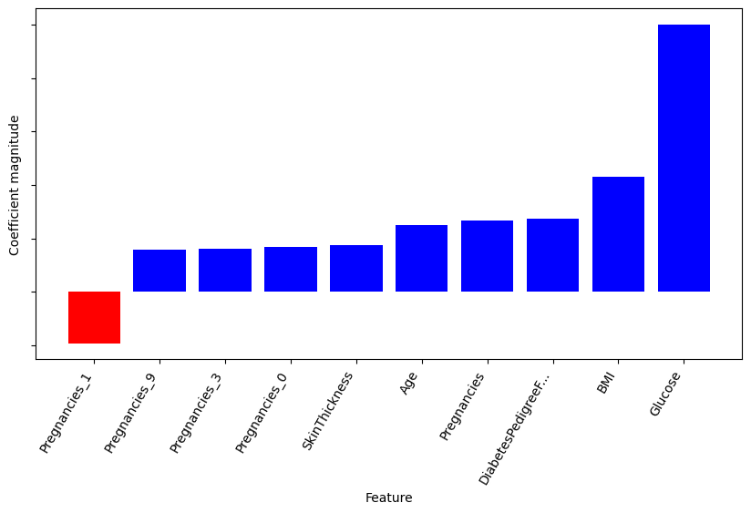

```python
dabl.explain(ref_model)
```

```python
# checking the reference model for the data where missing values were removed instead of imputation

ref_model_no_missing_df = dabl.SimpleClassifier(random_state=0).fit(diabetes_data_without_missing_vals, target_col="Outcome")
ref_model_no_missing_df
```

```
Running DummyClassifier()
accuracy: 0.668 average_precision: 0.332 roc_auc: 0.500 recall_macro: 0.500 f1_macro: 0.401
=== new best DummyClassifier() (using recall_macro):
accuracy: 0.668 average_precision: 0.332 roc_auc: 0.500 recall_macro: 0.500 f1_macro: 0.401

Running GaussianNB()
accuracy: 0.633 average_precision: 0.489 roc_auc: 0.671 recall_macro: 0.575 f1_macro: 0.543
=== new best GaussianNB() (using recall_macro):
accuracy: 0.633 average_precision: 0.489 roc_auc: 0.671 recall_macro: 0.575 f1_macro: 0.543

Running MultinomialNB()
accuracy: 0.714 average_precision: 0.542 roc_auc: 0.676 recall_macro: 0.627 f1_macro: 0.633
=== new best MultinomialNB() (using recall_macro):
accuracy: 0.714 average_precision: 0.542 roc_auc: 0.676 recall_macro: 0.627 f1_macro: 0.633

Running DecisionTreeClassifier(class_weight='balanced', max_depth=1)
accuracy: 0.763 average_precision: 0.545 roc_auc: 0.753 recall_macro: 0.753 f1_macro: 0.741
=== new best DecisionTreeClassifier(class_weight='balanced', max_depth=1) (using recall_macro):
accuracy: 0.763 average_precision: 0.545 roc_auc: 0.753 recall_macro: 0.753 f1_macro: 0.741

Running DecisionTreeClassifier(class_weight='balanced', max_depth=5)
accuracy: 0.750 average_precision: 0.572 roc_auc: 0.757 recall_macro: 0.751 f1_macro: 0.732
Running DecisionTreeClassifier(class_weight='balanced', min_impurity_decrease=0.01)
accuracy: 0.752 average_precision: 0.591 roc_auc: 0.777 recall_macro: 0.763 f1_macro: 0.738
=== new best DecisionTreeClassifier(class_weight='balanced', min_impurity_decrease=0.01) (using recall_macro):
accuracy: 0.752 average_precision: 0.591 roc_auc: 0.777 recall_macro: 0.763 f1_macro: 0.738

Running LogisticRegression(C=0.1, class_weight='balanced', max_iter=1000)
accuracy: 0.760 average_precision: 0.736 roc_auc: 0.848 recall_macro: 0.749 f1_macro: 0.739
Running LogisticRegression(class_weight='balanced', max_iter=1000)
accuracy: 0.768 average_precision: 0.707 roc_auc: 0.825 recall_macro: 0.749 f1_macro: 0.742

Best model:
DecisionTreeClassifier(class_weight='balanced', min_impurity_decrease=0.01)
Best Scores:
accuracy: 0.752 average_precision: 0.591 roc_auc: 0.777 recall_macro: 0.763 f1_macro: 0.738
```

```
SimpleClassifier(random_state=0)
```

#### Task II (e): Running appropriate (multiple) Classification Models on the Data to determine the best model

```python
# custom function which accepts the ML model and the spittled data, and returns the training and testing accuracy
# this fuction is quick way to getting the accuracies, just by creating the model and passing it with the data to this function

def ML_model_classifier(model, X_train, X_test, y_train, y_test, verbose=0):

    clf.fit(X_train, y_train)

    y_pred_train = clf.predict(X_train)
    y_pred_test = clf.predict(X_test)

    train_acc = round((accuracy_score(y_train, y_pred_train)*100),2)
    test_acc = round((accuracy_score(y_test, y_pred_test)*100),2)

    if verbose:
        print(f'Model: {model}')
        print(f'Training Accuracy: {train_acc}%')
        print(f'Test Accuracy: {test_acc}%')

    return model, train_acc, test_acc
```

```python
# Running the data with LogisticRegression

clf = LogisticRegression(C=0.1, class_weight='balanced', max_iter=1000)
model, train_acc, test_acc = ML_model_classifier(clf, X_train, X_test, y_train, y_test, verbose = 1)
```

```
Model: LogisticRegression(C=0.1, class_weight='balanced', max_iter=1000)
Training Accuracy: 72.74%
Test Accuracy: 80.43%
```

```python
# Running the data with DecisionTreeClassifier

clf = DecisionTreeClassifier(class_weight='balanced')
model, train_acc, test_acc = ML_model_classifier(clf, X_train, X_test, y_train, y_test, verbose = 1)
```

```
Model: DecisionTreeClassifier(class_weight='balanced')
Training Accuracy: 100.0%
Test Accuracy: 71.74%
```

```python
# Running the data with RandomForestClassifier

clf = RandomForestClassifier(n_estimators=200, class_weight='balanced')
model, train_acc, test_acc = ML_model_classifier(clf, X_train, X_test, y_train, y_test, verbose = 1)
```

```
Model: RandomForestClassifier(class_weight='balanced', n_estimators=200)
Training Accuracy: 100.0%
Test Accuracy: 81.52%
```

```python
# Running the data with SVC

clf = SVC(kernel = 'linear',gamma = 'scale', shrinking = False)
model, train_acc, test_acc = ML_model_classifier(clf, X_train, X_test, y_train, y_test, verbose = 1)
```

```
Model: SVC(kernel='linear', shrinking=False)
Training Accuracy: 77.74%
Test Accuracy: 77.17%
```

```python
# Running the data with XGBoost Classifier

xgb_classifier = xgb.XGBClassifier()
model, train_acc, test_acc = ML_model_classifier(xgb_classifier, X_train, X_test, y_train, y_test, verbose = 1)
```

```
Model: XGBClassifier(base_score=None, booster=None, colsample_bylevel=None,
              colsample_bynode=None, colsample_bytree=None,
              enable_categorical=False, gamma=None, gpu_id=None,
              importance_type=None, interaction_constraints=None,
              learning_rate=None, max_delta_step=None, max_depth=None,
              min_child_weight=None, missing=nan, monotone_constraints=None,
              n_estimators=100, n_jobs=None, num_parallel_tree=None,
              predictor=None, random_state=None, reg_alpha=None,
              reg_lambda=None, scale_pos_weight=None, subsample=None,
              tree_method=None, validate_parameters=None, verbosity=None)
Training Accuracy: 77.74%
Test Accuracy: 77.17%
```

```python
# Running the data with KNeighborsClassifier

clf = KNeighborsClassifier()
model, train_acc, test_acc = ML_model_classifier(clf, X_train, X_test, y_train, y_test, verbose = 1)
```

```
Model: KNeighborsClassifier()
Training Accuracy: 83.49%
Test Accuracy: 77.17%
```

**Analysis Summary**:

#### Task II (f): KNN Model Analysis on training and testing data accuracy

```python
# Getting the training and test accuracies in a list for different values of K (of KNN Model)

train_acc_list = []
test_acc_list = []

for n in range(5, 101,5):
    clf = KNeighborsClassifier(n_neighbors=n)
    model, train_acc, test_acc = ML_model_classifier(clf, X_train, X_test, y_train, y_test, verbose=0)
    train_acc_list.append(train_acc)
    test_acc_list.append(test_acc)
```

```python
print(train_acc_list[:10])
print(test_acc_list[:10])
```

```
[83.49, 80.61, 79.27, 78.5, 78.12, 78.31, 77.54, 77.74, 77.54, 76.58]
[77.17, 75.0, 73.91, 73.91, 77.17, 78.26, 79.35, 78.26, 77.17, 77.17]
```

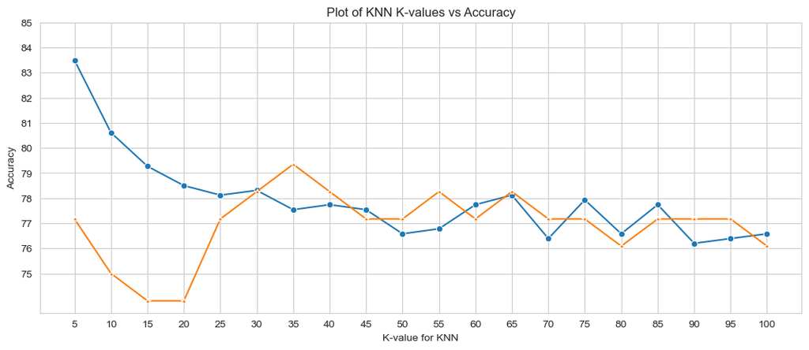

```python
sns.set_style("whitegrid")

plt.figure(figsize=(13,5))
sns.lineplot(y = train_acc_list, x = range(5, 101,5), marker='o')
sns.lineplot(y = test_acc_list, x = range(5, 101,5), marker='*')
plt.xticks(range(5, 101,5))
plt.yticks(range(75,86,1))
plt.title("Plot of KNN K-values vs Accuracy")
plt.ylabel("Accuracy")
plt.xlabel("K-value for KNN")
plt.show()
```

```python
knn_accuracy_df  = pd.DataFrame((train_acc_list, test_acc_list),
                                index = ['knn_train_accuracy', 'knn_test_accuracy'],
                                columns = range(5, 101,5))

knn_accuracy_df
```

|  | 5 | 10 | 15 | 20 | 25 | 30 | 35 | 40 | 45 | 50 | 55 | 60 | 65 | 70 | 75 | 80 | 85 | 90 | 95 | 100 |
| --- | --- | --- | --- | --- | --- | --- | --- | --- | --- | --- | --- | --- | --- | --- | --- | --- | --- | --- | --- | --- |
| knn_train_accuracy | 83.49 | 80.61 | 79.27 | 78.50 | 78.12 | 78.31 | 77.54 | 77.74 | 77.54 | 76.58 | 76.78 | 77.74 | 78.12 | 76.39 | 77.93 | 76.58 | 77.74 | 76.20 | 76.39 | 76.58 |
| knn_test_accuracy | 77.17 | 75.00 | 73.91 | 73.91 | 77.17 | 78.26 | 79.35 | 78.26 | 77.17 | 77.17 | 78.26 | 77.17 | 78.26 | 77.17 | 77.17 | 76.09 | 77.17 | 77.17 | 77.17 | 76.09 |

```python
# Getting the training and test accuracies in a list for different values of K (of KNN Model)

train_acc_list = []
test_acc_list = []

for n in range(25, 36,1):
    clf = KNeighborsClassifier(n_neighbors=n)
    model, train_acc, test_acc = ML_model_classifier(clf, X_train, X_test, y_train, y_test, verbose=0)
    train_acc_list.append(train_acc)
    test_acc_list.append(test_acc)
```

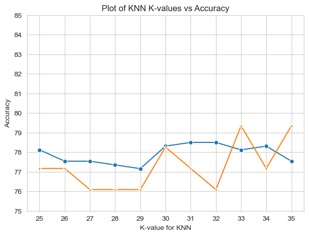

```python
sns.set_style("whitegrid")

plt.figure(figsize=(7,5))
sns.lineplot(y = train_acc_list, x = range(25, 36,1), marker='o')
sns.lineplot(y = test_acc_list, x = range(25, 36,1), marker='*')
plt.xticks(range(25, 36,1))
plt.yticks(range(75,86,1))
plt.title("Plot of KNN K-values vs Accuracy")
plt.ylabel("Accuracy")
plt.xlabel("K-value for KNN")
plt.show()
```

```python
# re-running the classifier with k=30 (as in graph above, 30 neighbours gives optimum accuracy for training and testing data)

clf = KNeighborsClassifier(n_neighbors=30)
model, train_acc, test_acc = ML_model_classifier(clf, X_train, X_test, y_train, y_test, verbose = 1)
```

```
Model: KNeighborsClassifier(n_neighbors=30)
Training Accuracy: 78.31%
Test Accuracy: 78.26%
```

#### Task II (g): KNN Model Analysis on training and testing data accuracy (Principle Components)

```python
train_acc_list_pc = []
test_acc_list_pc = []

for n in range(5, 101, 5):
    clf = KNeighborsClassifier(n_neighbors=n)
    model, train_acc, test_acc = ML_model_classifier(clf, X_train_pc, X_test_pc, y_train, y_test)
    train_acc_list_pc.append(train_acc)
    test_acc_list_pc.append(test_acc)
```

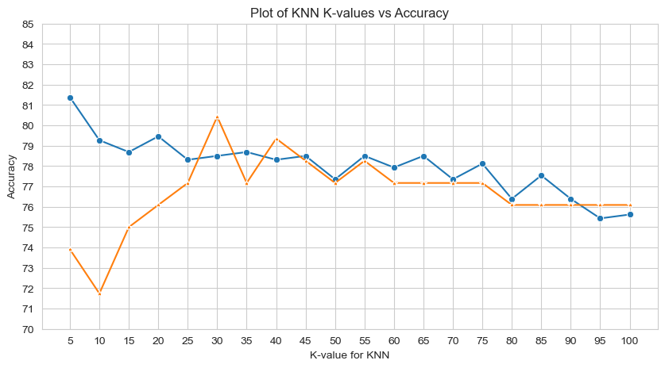

```python
plt.figure(figsize=(10,5))
sns.lineplot(y = train_acc_list_pc, x = range(5, 101, 5), marker='o')
sns.lineplot(y = test_acc_list_pc, x = range(5, 101, 5), marker='*')
plt.xticks(range(5, 101, 5))
plt.yticks(range(70,86,1))
plt.title("Plot of KNN K-values vs Accuracy")
plt.ylabel("Accuracy")
plt.xlabel("K-value for KNN")
plt.show()
```

**Analysis Summary**:

- Since KNN model gave highest accuracy in training data, this was optimized for best K value using loops and graphs. (even though the highest accuracy on training data is given by random forest and decision tress, however, those model are overfitting)
- It was found that when k=30, the model gave its best accuracy on training and testing data of about 78% without overfitting.
- KNN model was also checked for its best values using 7 principle components, however, the training and testing accuracies of about 78% converged at k = 45. Moreover, there was no significant dimensionality reduction achieved with PCA, therefore it is disregarded in further metric calculations.

#### Task II (h): Hyperparameter Tuning of Random Forest using GridSearchCV

```python
rf = RandomForestClassifier(n_jobs=-1)

params = {
    'max_depth': [10, 20, 25, 30, 35, 40, 50, 100],
    'min_samples_leaf': [2,5,7,9,15, 25, 50],
    'n_estimators': [150, 200, 250, 300, 350, 400, 500, 700]
}
```

```python
# Instantiate the grid search model

grid_search = GridSearchCV(estimator=rf,
                           param_grid=params,
                           cv = 10,
                           n_jobs=-1, verbose=2, scoring="accuracy", return_train_score=True)
```

```python
grid_search.fit(X_train, y_train)
```

```
Fitting 10 folds for each of 448 candidates, totalling 4480 fits
```

```
GridSearchCV(cv=10, estimator=RandomForestClassifier(n_jobs=-1), n_jobs=-1,
             param_grid={'max_depth': [10, 20, 25, 30, 35, 40, 50, 100],
                         'min_samples_leaf': [2, 5, 7, 9, 15, 25, 50],
                         'n_estimators': [150, 200, 250, 300, 350, 400, 500,
                                          700]},
             return_train_score=True, scoring='accuracy', verbose=2)
```

```python
grid_search.cv_results_.keys()
```

```
dict_keys(['mean_fit_time', 'std_fit_time', 'mean_score_time', 'std_score_time', 'param_max_depth', 'param_min_samples_leaf', 'param_n_estimators', 'params', 'split0_test_score', 'split1_test_score', 'split2_test_score', 'split3_test_score', 'split4_test_score', 'split5_test_score', 'split6_test_sco…
```

```python
grid_search.cv_results_['mean_train_score'][:10]
```

```
array([0.95947962, 0.96012019, 0.96118537, 0.96097215, 0.96118583,
       0.96139859, 0.96140042, 0.95990742, 0.902324  , 0.89933711])
```

```python
grid_cv_scores = pd.DataFrame([grid_search.cv_results_['mean_train_score'], grid_search.cv_results_['mean_test_score']]).T
grid_cv_scores.columns = ['mean_train_score', 'mean_test_score']
grid_cv_scores.head(7)
```

|  | mean_train_score | mean_test_score |
| --- | --- | --- |
| 0 | 0.959480 | 0.765965 |
| 1 | 0.960120 | 0.767816 |
| 2 | 0.961185 | 0.765893 |
| 3 | 0.960972 | 0.767816 |
| 4 | 0.961186 | 0.765893 |
| 5 | 0.961399 | 0.765856 |
| 6 | 0.961400 | 0.767816 |

```python
grid_search.best_score_
```

```
0.7851596516690856
```

```python
best_parameters = grid_search.best_params_
print(best_parameters)
```

```
{'max_depth': 100, 'min_samples_leaf': 15, 'n_estimators': 700}
```

```python
rf_best = grid_search.best_estimator_
rf_best
```

```
RandomForestClassifier(max_depth=100, min_samples_leaf=15, n_estimators=700,
                       n_jobs=-1)
```

#### Task II (i): Using best model obtained from Gridsearch for predictions

```python
rf_best.fit(X_train, y_train)

y_pred_train = rf_best.predict(X_train)
y_pred_test = rf_best.predict(X_test)
```

```python
print(f'Training Accuracy: {round((accuracy_score(y_train, y_pred_train)*100),2)}%')
print(f'Test Accuracy: {round((accuracy_score(y_test, y_pred_test)*100),2)}%')
```

```
Training Accuracy: 81.77%
Test Accuracy: 73.91%
```

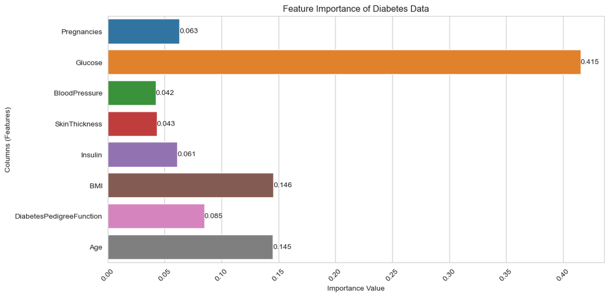

```python
# Visualizing feature importance of diabetes data using random forest

plt.figure(figsize=(12,6))
ax = sns.barplot(y = diabetes_data_missing_imputed_outlier_removed.columns[:-1], x = rf_best.feature_importances_)
ax.bar_label(ax.containers[0], fmt='%.3f')
plt.title("Feature Importance of Diabetes Data")
plt.xlabel("Importance Value")
plt.ylabel("Columns (Features)")
plt.xticks(rotation=45)
plt.show()
```

**Analysis Summary**:

#### Task II (j): Final Model (KNN) Analysis of Performance

```python
# Best model obtained was KNN with neighbors = 30

clf = KNeighborsClassifier(n_neighbors=30)
model, train_acc, test_acc = ML_model_classifier(clf, X_train, X_test, y_train, y_test, verbose = 1)
```

```
Model: KNeighborsClassifier(n_neighbors=30)
Training Accuracy: 78.31%
Test Accuracy: 78.26%
```

```python
# Getting training and test predictions

y_pred_train = model.predict(X_train)
y_pred_test = model.predict(X_test)
```

```python
y_pred_test[:10]
```

```
array([1, 0, 0, 0, 0, 0, 0, 1, 0, 0], dtype=int64)
```

```python
print(confusion_matrix(y_test, y_pred_test))
```

```
[[54  2]
 [18 18]]
```

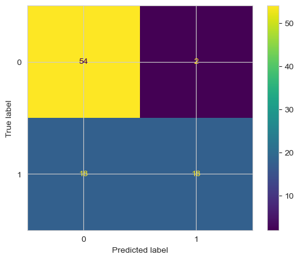

```python
# Visualizing confusion matrix in a better way

cm = confusion_matrix(y_test, y_pred_test, labels=model.classes_)
disp = ConfusionMatrixDisplay(confusion_matrix=cm, display_labels=model.classes_)
disp.plot()
plt.show()
```

```python
print(classification_report(y_test, y_pred_test))
```

```
              precision    recall  f1-score   support

           0       0.75      0.96      0.84        56
           1       0.90      0.50      0.64        36

    accuracy                           0.78        92
   macro avg       0.82      0.73      0.74        92
weighted avg       0.81      0.78      0.77        92
```

```python
tn, fp, fn, tp = confusion_matrix(y_test, y_pred_test, labels=model.classes_).ravel()
specificity = tn / (tn+fp)
sensitivity = tp / (tp+fn)
```

```python
print(f"True Negative: {tn}")
print(f"False Positive: {fp}")
print(f"False Negative: {fn}")
print(f"True Positive: {tp}")
```

```
True Negative: 54
False Positive: 2
False Negative: 18
True Positive: 18
```

```python
print(f"Sensitivity/Recall: {round(sensitivity,2)}")
print(f"Specificity: {round(specificity,2)}")
```

```
Sensitivity/Recall: 0.5
Specificity: 0.96
```

```python
# Getting predicted probabilites values, for plotting of ROC curve

knn_probs = model.predict_proba(X_test)[:, 1]
```

```python
knn_probs[:10]
```

```
array([0.6       , 0.23333333, 0.23333333, 0.33333333, 0.1       ,
       0.43333333, 0.33333333, 0.66666667, 0.1       , 0.23333333])
```

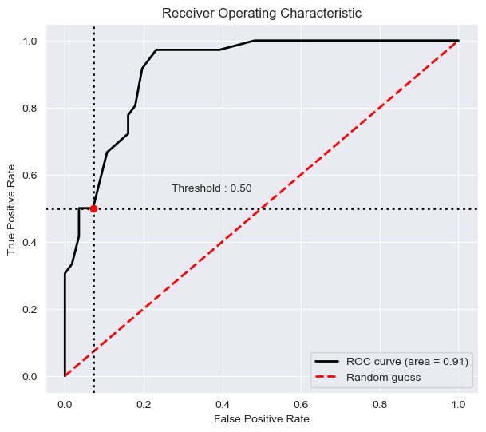

```python
# plotting ROC Curve

# Visualisation with plot_metric
bc = BinaryClassification(y_test, knn_probs, labels=["Class 1", "Class 2"])

# Figures
plt.figure(figsize=(7,6))
bc.plot_roc_curve()
plt.show()
```

**Analysis Summary**:

- Overall, the final best model is KNN with K=30.
  - Training Accuracy: 78.31%
  - Test Accuracy: 78.26%
- Following are the confusion metrics obtained on test data:
  - True Negative: 54
  - False Positive: 2
  - False Negative: 18
  - True Positive: 18
  - Sensitivity/Recall: 0.5
  - Specificity: 0.96
  - ROC Curve Area: 0.91

#### Task II (k): Checking the Accuracy of KNN with Cross Validation.

```python
%%time

# Not defining model again because we already have it in 'model' variable

k_folds = KFold(n_splits = 10)

scores = cross_val_score(model, X, y, cv = k_folds)
```

```
CPU times: total: 234 ms
Wall time: 226 ms
```

```python
print("Cross Validation Scores: \n", scores)
print(f"\nAverage CV Score: {round(scores.mean()*100,2)}%")
print("\nNumber of CV Scores used in Average: ", len(scores))
```

```
Cross Validation Scores:
 [0.69354839 0.80645161 0.72580645 0.60655738 0.70491803 0.73770492
 0.80327869 0.80327869 0.75409836 0.78688525]

Average CV Score: 74.23%

Number of CV Scores used in Average:  10
```

#### Task II (l): Predicition of test datapoints and comparison with actual datapoints

```python
# since predicted test values were in numpy array type, converting it to series type

y_pred_test = pd.Series(y_pred_test, index=y_test.index)
```

```python
type(y_test), type(y_pred_test)
```

```
(pandas.core.series.Series, pandas.core.series.Series)
```

```python
# preparing a dataframe to get th actual values and predicted values side by side

actual_pred_comparison = pd.DataFrame([y_test, y_pred_test], index=['actual_outcomes', 'predicted_outcomes']).T
actual_pred_comparison.head(6)
```

|  | actual_outcomes | predicted_outcomes |
| --- | --- | --- |
| 0 | 1 | 1 |
| 121 | 0 | 0 |
| 325 | 0 | 0 |
| 214 | 1 | 0 |
| 651 | 0 | 0 |
| 345 | 0 | 0 |

```python
# exporting the actual vs predicted values comparison dataframe as csv file (for reporting and submission purpose)

actual_pred_comparison.to_csv('actual_pred_comparison.csv', index = False)
```

### Task III: Tableau Report

#### Task III (a): Exporting treated data for Tableau Analysis

```python
diabetes_data_missing_imputed_outlier_removed.to_csv("diabetes_data_for_tableau_report.csv", index = False)
```

#### Task III (b): Link of Tableau Dashboard

Tableau Report Link - https://public.tableau.com/app/profile/lavkush.singh4748/viz/PCDS-DataScienceCapstoneTableauReport/ProportionofDiabeticPopulation